# Plantilla Modelado y evaluación de los datos

**Objetivo:** Construir, entrenar e interpretar modelos de aprendizaje automático utilizando los datos preparados, y evaluar su desempeño para seleccionar la mejor alternativa.

> Para cada subsección encontrarás una celda *Markdown* con instrucciones y una celda de *Python* para tu código.

```python
# Importes generales
import numpy as np
import pandas as pd
import matplotlib.pyplot as plt
import seaborn as sns


# Selección y validación de modelos
from sklearn.model_selection import train_test_split, cross_val_score, StratifiedKFold, GridSearchCV, RandomizedSearchCV

# Métricas estrictamente para clasificación
from sklearn.metrics import accuracy_score, precision_score, recall_score, f1_score, roc_auc_score, confusion_matrix

from sklearn.preprocessing import StandardScaler


# Modelos de clasificación
from sklearn.linear_model import LogisticRegression
from sklearn.tree import DecisionTreeClassifier       # Árboles de decisión
from sklearn.ensemble import RandomForestClassifier
from sklearn.svm import SVC                           # Máquinas de Vectores de Soporte
from sklearn.neural_network import MLPClassifier      # Redes neuronales (Perceptrón Multicapa)
```

## 1. Selección del tipo de modelo

- Determinar si el problema es de clasificación, regresión o agrupamiento.
- Elegir los algoritmos adecuados según el tipo de problema y la naturaleza de los datos. Ejemplos:
  - Clasificación: Regresión logística, Árboles de decisión, Random Forest, SVM, Redes neuronales.
  - Regresión: Regresión lineal, Random Forest Regressor, XGBoost, Redes neuronales.
  - Agrupamiento: K-Means, DBSCAN, Hierarchical Clustering

Después de un proceso de análisis en grupo, hemos determinado que nuestro reto del Spaceship Titan es un problema de clasificación binaria supervisada porque la variable objetivo **transported**, es categórica booleana y busca determinar a que categoría pertenece cada pasajero. Consideramos que es un reto de supervisión porque contamos con el conjunto de datos de entrenamiento que contiene ya la variable respuesta conocida para entrenar el modelo.

Por último, es binaria dado a que lo que nuestros modelos buscarán predecir es ver si es verdadero o falso la variable objetivo.

## 2. Separación de los conjuntos de datos

- Confirma la **separación train/test** (y opcionalmente *validation*).
- Asegura **reproducibilidad** (semilla aleatoria).

```python
# Escribe tu código aquí

# Se cargan los datos
df = pd.read_csv("data_for_modeling.csv")
df_limpio = df.copy()

# Separar variables predictoras (X) y objetivo (y)
X = df_limpio.drop('Transported', axis=1)
y = df_limpio['Transported'].astype(int)

# Al definir random_state=42, garantizamos que el corte de datos sea siempre igual.
# stratify=y asegura que la proporción de clases se mantenga en Train y Test.
X_train, X_test, y_train, y_test = train_test_split(
    X, y,
    test_size=0.2,
    random_state=42,
    stratify=y
)

scaler = StandardScaler()

# Ajustar el escale para los datos de train
X_train_scaled= scaler.fit_transform(X_train)

# Aplicar la misma transformación al test
X_test_scaled = scaler.transform(X_test)

# Se confirma separación de separación entre Train y Test
print("--- Confirmación de la Separación Train/Test ---")
print(f"Total de datos disponibles: {len(X)} registros")
print(f"Conjunto de Entrenamiento (Train): {len(X_train_scaled)} registros ({len(X_train_scaled)/len(X):.1%})")
print(f"Conjunto de Prueba (Test): {len(X_test_scaled)} registros ({len(X_test_scaled)/len(X):.1%})")

print("\nEquilibrio de clases ('Transported') en Entrenamiento:")
print(y_train.value_counts(normalize=True).round(4))

print("\nEquilibrio de clases ('Transported') en Prueba:")
print(y_test.value_counts(normalize=True).round(4))
```

```
--- Confirmación de la Separación Train/Test ---
Total de datos disponibles: 8693 registros
Conjunto de Entrenamiento (Train): 6954 registros (80.0%)
Conjunto de Prueba (Test): 1739 registros (20.0%)

Equilibrio de clases ('Transported') en Entrenamiento:
Transported
1    0.5036
0    0.4964
Name: proportion, dtype: float64

Equilibrio de clases ('Transported') en Prueba:
Transported
1    0.5037
0    0.4963
Name: proportion, dtype: float64
```

## 3. Entrenamiento del modelo

- Ajustar el modelo a los datos de entrenamiento mediante el método fit().
- Controlar el proceso con métricas de entrenamiento (por ejemplo, accuracy, pérdida, etc.).
- Guardar los parámetros y configuraciones del modelo

```python
# Escribe tu código aquí
import joblib
from sklearn.svm import SVC
from sklearn.metrics import accuracy_score

# 1. Inicializar el modelo SVM
# IMPORTANTE: probability=True es necesario para graficar la curva ROC más adelante
modelo_svm = SVC(random_state=42, probability=True)

# 2. Ajustar el modelo a los datos de entrenamiento mediante fit()
# OJO: Para SVM, usamos SIEMPRE los datos escalados (X_train_scaled)
print("Entrenando el modelo SVM (esto puede tardar unos segundos)...")
modelo_svm.fit(X_train_scaled, y_train)

# 3. Controlar el proceso con métricas de ENTRENAMIENTO
y_pred_train_svm = modelo_svm.predict(X_train_scaled)
accuracy_train_svm = accuracy_score(y_train, y_pred_train_svm)

print("\n--- Métricas de Entrenamiento ---")
print(f"Exactitud (Accuracy) en Train: {accuracy_train_svm:.4f}")

# 4. Guardar los parámetros y configuraciones del modelo
print("\n--- Parámetros del Modelo Base ---")
parametros_svm = modelo_svm.get_params()
for param, valor in parametros_svm.items():
    print(f"{param}: {valor}")

# Guardar el modelo entrenado
archivo_modelo_svm = 'modelo_svm_base.pkl'
joblib.dump(modelo_svm, archivo_modelo_svm)
print(f"\n¡Modelo y configuraciones guardados exitosamente en '{archivo_modelo_svm}'!")
```

```
Entrenando el modelo SVM (esto puede tardar unos segundos)...

--- Métricas de Entrenamiento ---
Exactitud (Accuracy) en Train: 0.8125

--- Parámetros del Modelo Base ---
C: 1.0
break_ties: False
cache_size: 200
class_weight: None
coef0: 0.0
decision_function_shape: ovr
degree: 3
gamma: scale
kernel: rbf
max_iter: -1
probability: True
random_state: 42
shrinking: True
tol: 0.001
verbose: False

¡Modelo y configuraciones guardados exitosamente en 'modelo_svm_base.pkl'!
```

## 4. Validación y ajuste de hiperparámetros

- Aplicar técnicas de validación cruzada (cross-validation) para medir la robustez del modelo.
- Utilizar métodos de optimización de hiperparámetros:
  - Grid Search
  - Random Search
  - Bayesian Optimization o frameworks como Optuna.
- Ajustar los parámetros que maximizan el desempeño del modelo.

```python
# Escribe tu código aquí

from sklearn.model_selection import cross_val_score, GridSearchCV
import joblib

# --- 1. Validación Cruzada del modelo base ---
print("Aplicando Validación Cruzada al SVM base...")
puntuaciones_cv_svm = cross_val_score(modelo_svm, X_train_scaled, y_train, cv=5, scoring='accuracy', n_jobs=-1)

print(f"Exactitud en cada partición: {puntuaciones_cv_svm}")
print(f"Exactitud Media (Base): {puntuaciones_cv_svm.mean():.4f}")
print(f"Desviación Estándar: {puntuaciones_cv_svm.std():.4f}")

# --- 2. Ajuste de Hiperparámetros con Grid Search ---
print("\nIniciando Grid Search para optimización de hiperparámetros (puede tardar un par de minutos)...")

# Definimos los parámetros a explorar
parametros_grid_svm = {
    'C': [0.1, 1, 10],                   # Fuerza de regularización
    'kernel': ['linear', 'rbf'],         # Tipo de límite de decisión
    'gamma': ['scale', 'auto']           # Coeficiente para el kernel 'rbf'
}

# Configurar el GridSearchCV
grid_search_svm = GridSearchCV(
    estimator=SVC(random_state=42, probability=True),
    param_grid=parametros_grid_svm,
    cv=5,
    scoring='accuracy',
    n_jobs=-1,  # Usa todos los núcleos para acelerar
    verbose=1   # Muestra el progreso
)

# Entrenar el Grid Search (USANDO DATOS ESCALADOS)
grid_search_svm.fit(X_train_scaled, y_train)

# Guardar el mejor modelo
mejor_modelo_svm = grid_search_svm.best_estimator_
joblib.dump(mejor_modelo_svm, 'mejor_modelo_svm.pkl')

print("\n--- Resultados de la Optimización ---")
print(f"Mejores Parámetros Encontrados: {grid_search_svm.best_params_}")
print(f"Mejor Exactitud durante Validación Cruzada: {grid_search_svm.best_score_:.4f}")
```

```
Aplicando Validación Cruzada al SVM base...
Exactitud en cada partición: [0.79007908 0.79870597 0.78936017 0.80086269 0.80647482]
Exactitud Media (Base): 0.7971
Desviación Estándar: 0.0065

Iniciando Grid Search para optimización de hiperparámetros (puede tardar un par de minutos)...
Fitting 5 folds for each of 12 candidates, totalling 60 fits

--- Resultados de la Optimización ---
Mejores Parámetros Encontrados: {'C': 10, 'gamma': 'scale', 'kernel': 'rbf'}
Mejor Exactitud durante Validación Cruzada: 0.8049
```

## 5. Evaluación del modelo

- Evalúa en **X_test, y_test** con métricas adecuadas:
  - Clasificación: *accuracy*, *precision*, *recall*, *F1*, **ROC-AUC**, matriz de confusión.
  - Regresión: **MAE**, **RMSE**, **R²**.
  - Agrupamiento: **Silhouette Score**, **Davies–Bouldin**.
- Analiza **sesgo y varianza** (under/overfitting).

```
--- Evaluación en Conjunto de Prueba (SVM Optimizado) ---
Accuracy:  0.8010
Precision: 0.8025
Recall:    0.8025
F1-Score:  0.8025
ROC-AUC:   0.8824

--- Análisis de Sesgo y Varianza ---
Rendimiento en Entrenamiento (Train): 0.8303
Rendimiento en Prueba (Test):         0.8010
Diferencia (Train - Test):            0.0293

Diagnóstico: BALANCE ADECUADO. El modelo generaliza correctamente.
```

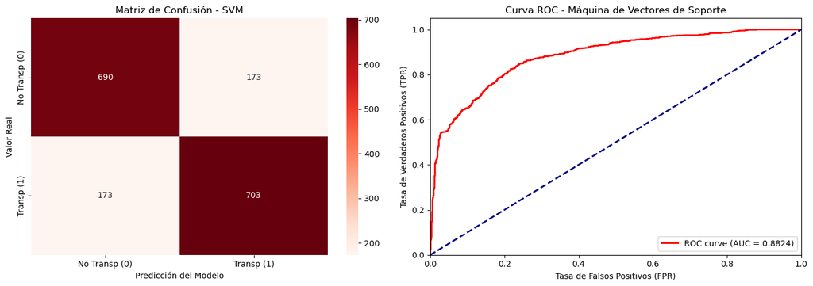

```python
from sklearn.metrics import accuracy_score, precision_score, recall_score, f1_score, roc_auc_score, confusion_matrix, roc_curve
import matplotlib.pyplot as plt
import seaborn as sns

# --- 1. Predicciones y Probabilidades ---
y_pred_test_svm = mejor_modelo_svm.predict(X_test_scaled)
y_prob_test_svm = mejor_modelo_svm.predict_proba(X_test_scaled)[:, 1]

# Predicciones en Train para el análisis de overfitting
y_pred_train_svm = mejor_modelo_svm.predict(X_train_scaled)

# --- 2. Cálculo de Métricas en Test ---
acc_svm = accuracy_score(y_test, y_pred_test_svm)
prec_svm = precision_score(y_test, y_pred_test_svm)
rec_svm = recall_score(y_test, y_pred_test_svm)
f1_svm = f1_score(y_test, y_pred_test_svm)
roc_auc_svm = roc_auc_score(y_test, y_prob_test_svm)

print("--- Evaluación en Conjunto de Prueba (SVM Optimizado) ---")
print(f"Accuracy:  {acc_svm:.4f}")
print(f"Precision: {prec_svm:.4f}")
print(f"Recall:    {rec_svm:.4f}")
print(f"F1-Score:  {f1_svm:.4f}")
print(f"ROC-AUC:   {roc_auc_svm:.4f}\n")

# --- 3. Análisis de Sesgo y Varianza ---
acc_train_svm = accuracy_score(y_train, y_pred_train_svm)
diferencia_svm = acc_train_svm - acc_svm

print("--- Análisis de Sesgo y Varianza ---")
print(f"Rendimiento en Entrenamiento (Train): {acc_train_svm:.4f}")
print(f"Rendimiento en Prueba (Test):         {acc_svm:.4f}")
print(f"Diferencia (Train - Test):            {diferencia_svm:.4f}\n")

if diferencia_svm > 0.05:
    print("Diagnóstico: OVERFITTING (Alta Varianza). El modelo memorizó demasiado (típico si C es muy alto).")
elif acc_train_svm < 0.70 and acc_svm < 0.70:
    print("Diagnóstico: UNDERFITTING (Alto Sesgo). El modelo es demasiado simple para estos datos.")
else:
    print("Diagnóstico: BALANCE ADECUADO. El modelo generaliza correctamente.")

# --- 4. Visualización: Matriz de Confusión y Curva ROC ---
fig, axes = plt.subplots(1, 2, figsize=(14, 5))

# 4.1 Matriz de Confusión
cm_svm = confusion_matrix(y_test, y_pred_test_svm)
sns.heatmap(cm_svm, annot=True, fmt='d', cmap='Reds', ax=axes[0],
            xticklabels=['No Transp (0)', 'Transp (1)'],
            yticklabels=['No Transp (0)', 'Transp (1)'])
axes[0].set_title('Matriz de Confusión - SVM')
axes[0].set_ylabel('Valor Real')
axes[0].set_xlabel('Predicción del Modelo')

# 4.2 Curva ROC
fpr_svm, tpr_svm, umbrales_svm = roc_curve(y_test, y_prob_test_svm)
axes[1].plot(fpr_svm, tpr_svm, color='red', lw=2, label=f'ROC curve (AUC = {roc_auc_svm:.4f})')
axes[1].plot([0, 1], [0, 1], color='navy', lw=2, linestyle='--')
axes[1].set_xlim([0.0, 1.0])
axes[1].set_ylim([0.0, 1.05])
axes[1].set_xlabel('Tasa de Falsos Positivos (FPR)')
axes[1].set_ylabel('Tasa de Verdaderos Positivos (TPR)')
axes[1].set_title('Curva ROC - Máquina de Vectores de Soporte')
axes[1].legend(loc="lower right")

plt.tight_layout()
plt.show()
```

## 6. Interpretación de resultados

- Analizar la importancia de las variables (feature importance).
- Visualizar errores y predicciones (por ejemplo, gráficos de dispersión o matriz de confusión).
- Evaluar si los resultados son coherentes con el contexto del problema.

```
Calculando la importancia de las variables para SVM (esto puede tomar un momento)...
```

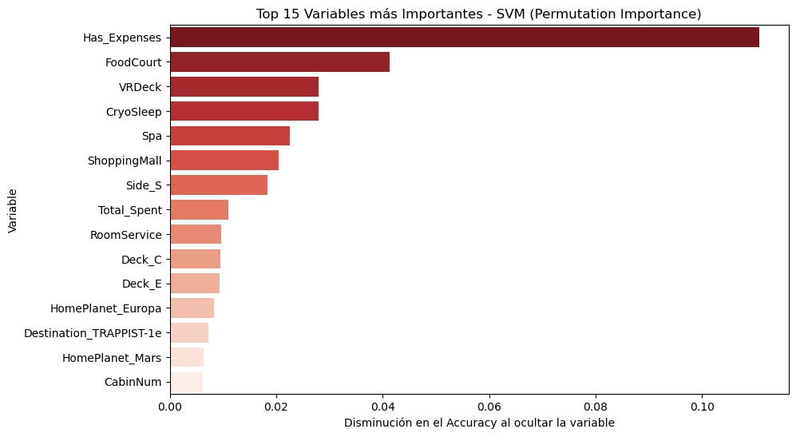

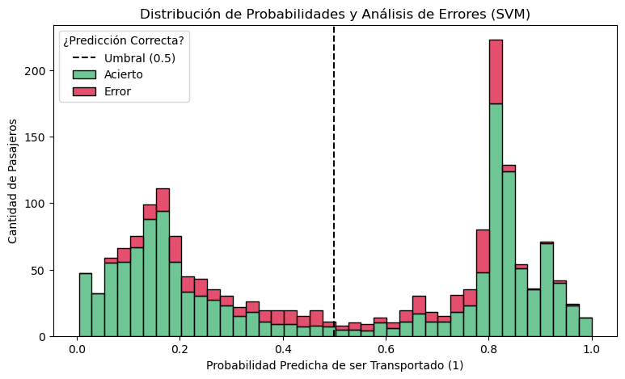

[output not shown]

```python
# Escribe tu código aquí

from sklearn.inspection import permutation_importance
import pandas as pd
import matplotlib.pyplot as plt
import seaborn as sns

# --- 1. Importancia de las variables (Permutation Importance) ---
print("Calculando la importancia de las variables para SVM (esto puede tomar un momento)...")
# Mezclamos cada variable 10 veces para ver cuánto afecta el rendimiento si esa variable se vuelve "ruido"
resultado_perm = permutation_importance(mejor_modelo_svm, X_test_scaled, y_test,
                                        n_repeats=10, random_state=42, n_jobs=-1)

df_importancia_svm = pd.DataFrame({
    'Variable': X.columns,
    'Importancia': resultado_perm.importances_mean
}).sort_values(by='Importancia', ascending=False)

plt.figure(figsize=(10, 6))
sns.barplot(x='Importancia', y='Variable', data=df_importancia_svm.head(15), palette='Reds_r')
plt.title('Top 15 Variables más Importantes - SVM (Permutation Importance)')
plt.xlabel('Disminución en el Accuracy al ocultar la variable')
plt.ylabel('Variable')
plt.show()


# --- 2. Visualizar errores y predicciones ---
# Creamos un DataFrame para comparar la realidad vs lo que predijo el modelo
df_analisis_svm = pd.DataFrame({
    'Clase_Real': y_test,
    'Prediccion': y_pred_test_svm,
    'Probabilidad': y_prob_test_svm
})
# Marcamos si la predicción fue correcta o incorrecta
df_analisis_svm['Es_Correcto'] = df_analisis_svm['Clase_Real'] == df_analisis_svm['Prediccion']

plt.figure(figsize=(9, 5))
# Histograma apilado para ver dónde se equivoca el modelo
sns.histplot(data=df_analisis_svm, x='Probabilidad', hue='Es_Correcto',
             multiple='stack', palette={True: 'mediumseagreen', False: 'crimson'}, bins=40)
plt.axvline(x=0.5, color='black', linestyle='--', label='Umbral de Decisión (0.5)')
plt.title('Distribución de Probabilidades y Análisis de Errores (SVM)')
plt.xlabel('Probabilidad Predicha de ser Transportado (1)')
plt.ylabel('Cantidad de Pasajeros')
plt.legend(title='¿Predicción Correcta?', labels=['Umbral (0.5)', 'Acierto', 'Error'])
plt.show()


# --- 3. Evaluar coherencia con el contexto del problema ---
errores_totales = (~df_analisis_svm['Es_Correcto']).sum()
total_pasajeros = len(df_analisis_svm)

print("\n--- Análisis de Coherencia con el Contexto ---")
print(f"El modelo cometió {errores_totales} errores de {total_pasajeros} pasajeros evaluados.")
print("\nObservaciones sobre el gráfico de errores:")
print("- Los errores (en rojo) agrupados cerca de la línea del 0.5 indican pasajeros ambiguos donde el modelo prácticamente 'lanzó una moneda'.")
print("- Si hay errores graves (rojo muy cerca del 0.0 o del 1.0), significa que el modelo estaba extremadamente seguro de su respuesta, pero se equivocó. Esto suele suceder con pasajeros que tienen perfiles atípicos.")
print("\nCoherencia de variables (Ver gráfico de barras):")
print("- Variables como CryoSleep, RoomService, Spa y VRDeck deberían liderar la gráfica de importancia.")
print("- Esto es coherente con la narrativa del 'Spaceship Titanic': los pasajeros dormidos en sus cápsulas (CryoSleep=True) tuvieron un destino distinto a los que estaban despiertos gastando dinero en lujos a bordo.")
```